# Project №3 “Mice”

# 1 Data preparation

## 1.1 Data set description

Data contains measurements of expression levels of 77 proteins of mice. There are 38 control mice and 34 mice with Down syndrome, for a total of 72 mice. 15 measurements were made for each mouse.

There are 8 classes of mice, which depend on genotype, behavior and treatment. More detailed data set description and data itself can be found [here](https://archive.ics.uci.edu/ml/datasets/Mice+Protein+Expression#).

## 1.2 Data processing

The initial data has following structure described in [S1].

We can notice that MouseID variable is represented in very inconvenient way and does not satisfy tidy-data requirements (mouse id and measurement id are combined in one variable). We can split it into two different variables: *MouseID* and *MeasurID*.

We also have 4 variables that represent mice groups: *Genotype*, *Treatment*, *Behavior* and *class*. We need to convert them to factors.

Now data structure looks like this. [S2]

## 1.3 Data set correctness verification

There are total of **72** mice and **15** measurements for each mouse.

They are divided in **8** groups.

Every group has a number of mice according to table:

|  | class | # of mice |
| --- | --- | --- |
| 1 | c-CS-m | 10 |
| 2 | c-CS-s | 9 |
| 3 | c-SC-m | 10 |
| 4 | c-SC-s | 9 |
| 5 | t-CS-m | 9 |
| 6 | t-CS-s | 7 |
| 7 | t-SC-m | 9 |
| 8 | t-SC-s | 9 |

Data seem to fit in description provided earlier, but there are only **552** rows without missing values, which is nearly half of whole data set.

## 1.4 Missing values

# 2 Data analysis

## 2.1 Does mice class affect protein production?

### 2.1.1 One-way ANOVA

In order to find out is there any differences in BDNF_N protein production between mice groups we will use one-way ANOVA.

We can see that **production of BDNF_N protein significantly depends on mice class (F =18.88 , p_value = 7.308e-24, df_1 = 7, df_2 = 1072).**

However we should ensure that our model satisfies usability conditions.

### 2.1.2 Model’s usability conditions verification

Here and further $3 \times mean(y)$ rule is used as a threshold for Cook distance.

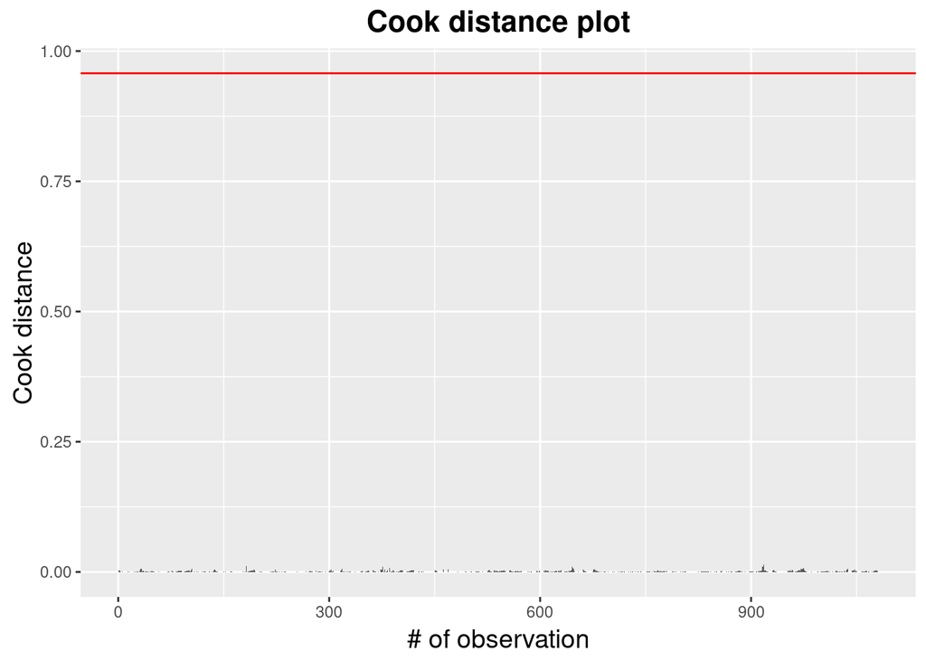

According to Cook distance plot, there are no critically influential observations.

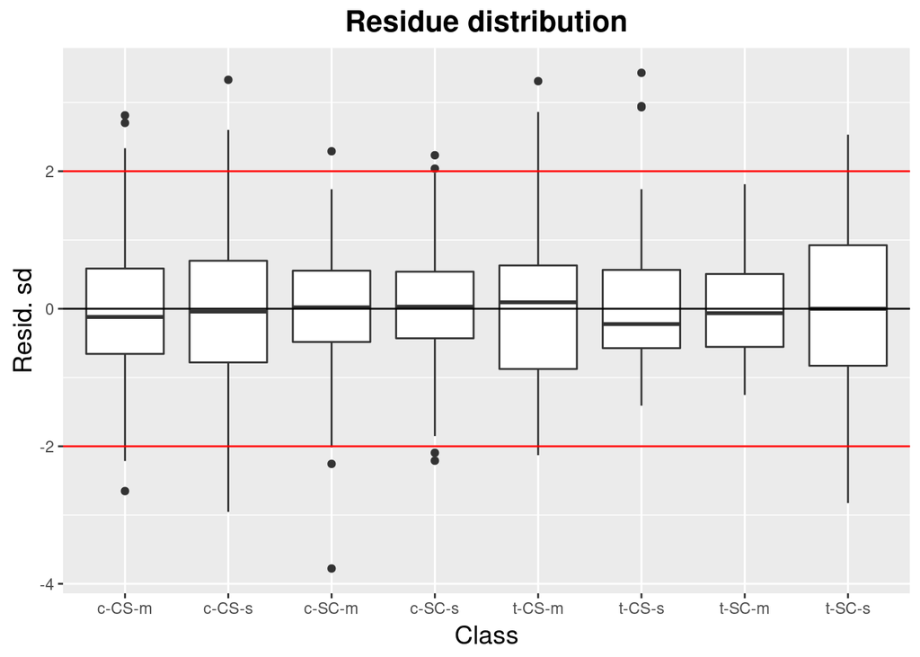

We can not observe any patterns in residue distribution. However some values have offset of more than 2 sigma. Luckily our groups are well balanced and we have a lot of observations, so such deviations may not be critical.

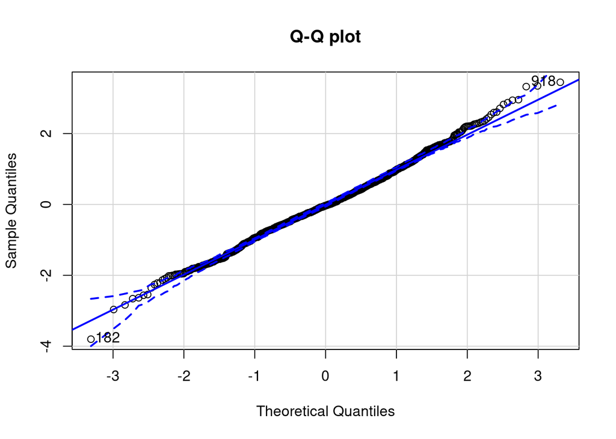

According to Q-Q plot, distribution of model’s residues seem to be more or less normal. However, Shapiro-Wilk normality test declines this hypothesis **(p-value = 0.006454, W = 0.996)**. This might happen because of several outliers.

### 2.1.3 Post-hoc test

Post-hoc tests are designed for identification of particular groups with significant differences between them.

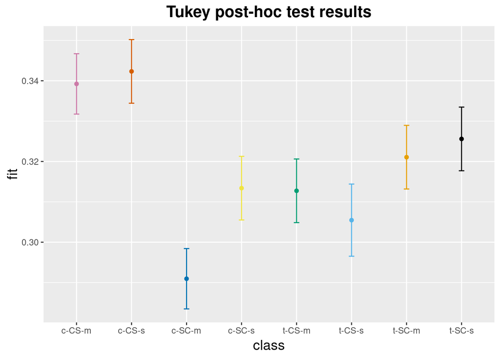

Post-hoc test showed that following groups significantly differ in BDNF_N production.

```
     class          t-value   p-value
c-SC-m - c-CS-m == 0  -8.955  < 0.001 ***
c-SC-s - c-CS-m == 0  -4.663  < 0.001 ***
t-CS-m - c-CS-m == 0  -4.782  < 0.001 ***
t-CS-s - c-CS-m == 0  -5.683  < 0.001 ***
t-SC-m - c-CS-m == 0  -3.278  0.02394 *
c-SC-m - c-CS-s == 0  -9.276  < 0.001 ***
c-SC-s - c-CS-s == 0  -5.090  < 0.001 ***
t-CS-m - c-CS-s == 0  -5.206  < 0.001 ***
t-CS-s - c-CS-s == 0  -6.067  < 0.001 ***
t-SC-m - c-CS-s == 0  -3.740  0.00468 **
c-SC-s - c-SC-m == 0   4.053  0.00120 **
t-CS-m - c-SC-m == 0   3.934  0.00223 **
t-SC-m - c-SC-m == 0   5.438  < 0.001 ***
t-SC-s - c-SC-m == 0   6.255  < 0.001 ***
t-SC-s - t-CS-s == 0   3.313  0.02134 *
```

## 2.2 Prediction of protein production

### 2.2.1 Building of linear model

In our data we have lots of contiguous numeric variables which can be used to build linear model. In theory, such model may be useful in prediction of protein production.

At first, we need to build linear model. The first thing to do is to build full model without factors (because we only use protein data as predictors). Full model summary can be seen here. [S3]

This model has a lot of insignificant predictors and most importantly perfectly collinear predictor, which does not allow to calculate **variance inflation factor** (VIF). Our next step is to remove perfectly collinear predictor **pS6_N**. Now we can calculate VIF for predictors of this model. [S4]

To select the best model we will use automatic backward selection which is implemented in *step* function. Manual selection has many benefits, but we have too many variables and it may take too long to select the best model, so in our case automatic approach is probably the best choice.

Although obtained model has relatively high R^2 **(R^2 = 0.8076)** [S5] . VIF values still show high multicollinearity [S6].

In the next model predictors were manually picked in such way, that there is no VIF greater than 2 [S7, S8].

### 2.2.2 Usability conditions verification

One usability condition (no multicollinearity) is verified. Next we need to verify others.

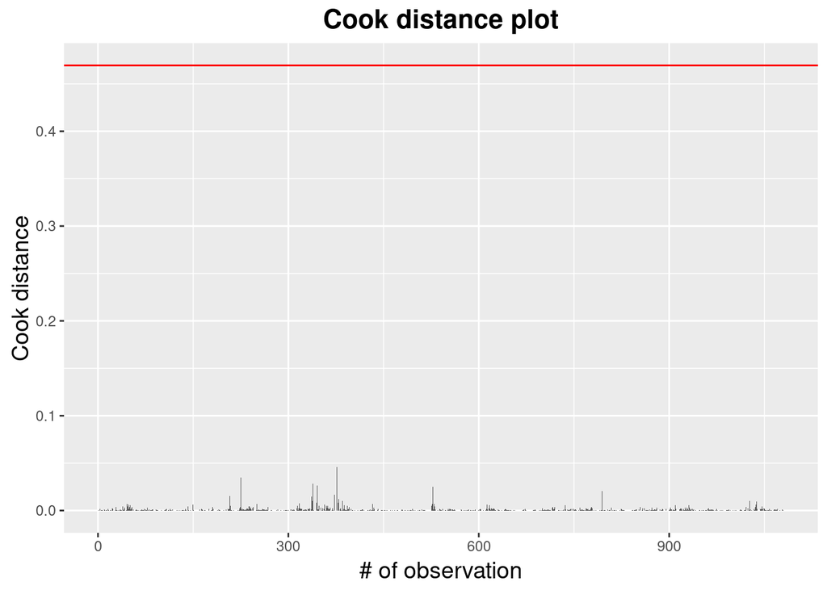

There are no influential observations in our data.

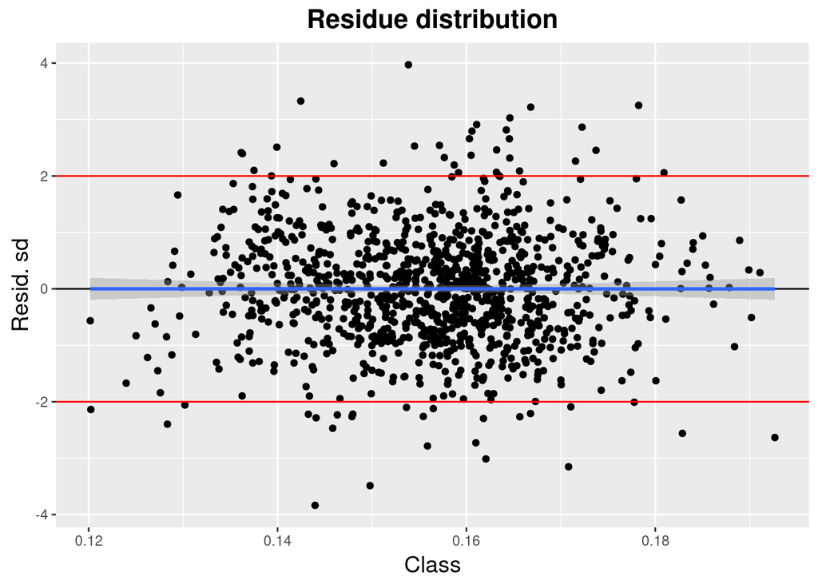

We cannot observe any patterns in residue distribution, but there are many residues that are more than 2 sigma away from fitted values.

[figure not shown]

From Q-Q plot we can see that residue distribution slightly differs from normal and Shapiro-Wilk test proves it **(p-value = 0.001067, W = 0.9949)**. But since we have a lot of data, this may be not critical.

Our model seem to almost fit into usability conditions. However it cannot be very useful due to low R^2 **(R^2 = 0.6092)**.

Summarizing this small research on models we can suggest that **protein expression data can not be used in building of reliable and precise linear model**.

## 2.3 Dimensionality reduction (PCA)

### 2.3.1 Ordination

PCA must be a good way to process our data. This will allow us to avoid multicollinearity. But first, we need to shrink our data, because we have 15 measurements of each mouse, but we want each observation to be a single mouse. So we can group our data by *MouseID* and summarize numerical variables by mean [S9]. Then we will build PCA model on obtained data [S10].

### 2.3.2 Interpretation of PCA

In the results of PCA we can see that the first components explain very small proportion of variation. PC1, PC2 and PC3 explain total of **0.54929**. Each of them explains **0.2565, 0.1980 and 0.09483** respectively.

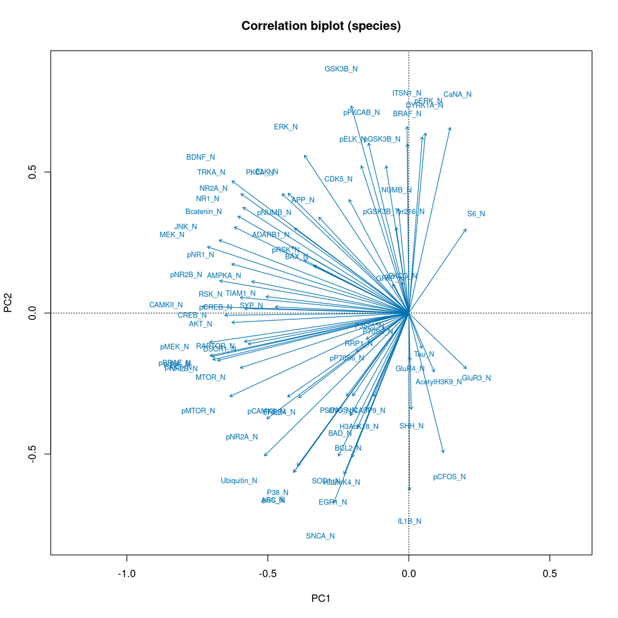

This chart shows us how each variable correlates with others and with 2 main components. It’s hard to interpreter because of over 70 variables, but we can see strong correlations between a lot of variables and PC1.

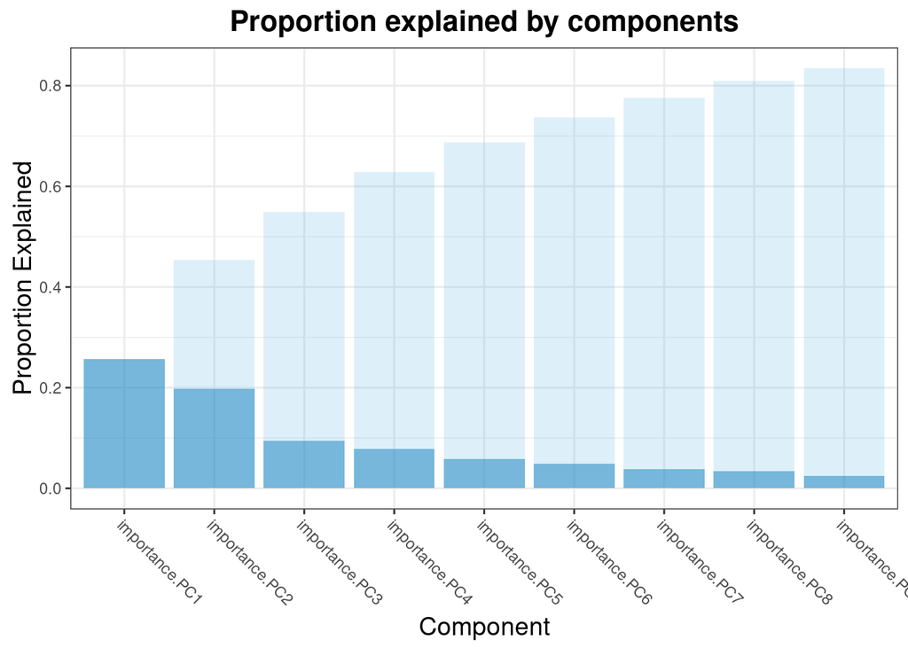

Here we can see proportion explained by each component (dark) and cumulative proportion (light). This is not so good, because we need at least 8 components to explain 80% data variation.

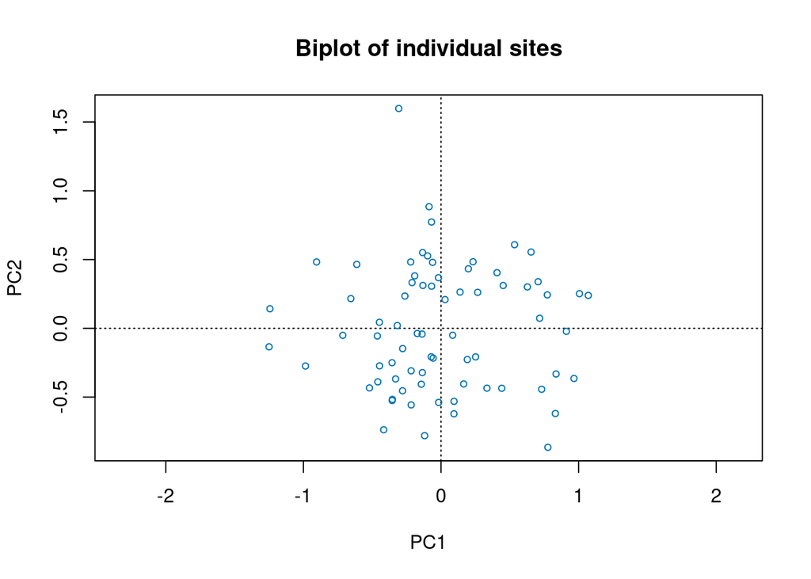

This chart depicts clusters of observations (sites). But this form is inconvenient, because does not show groups of mice. We can do this by colorizing such type of chart.

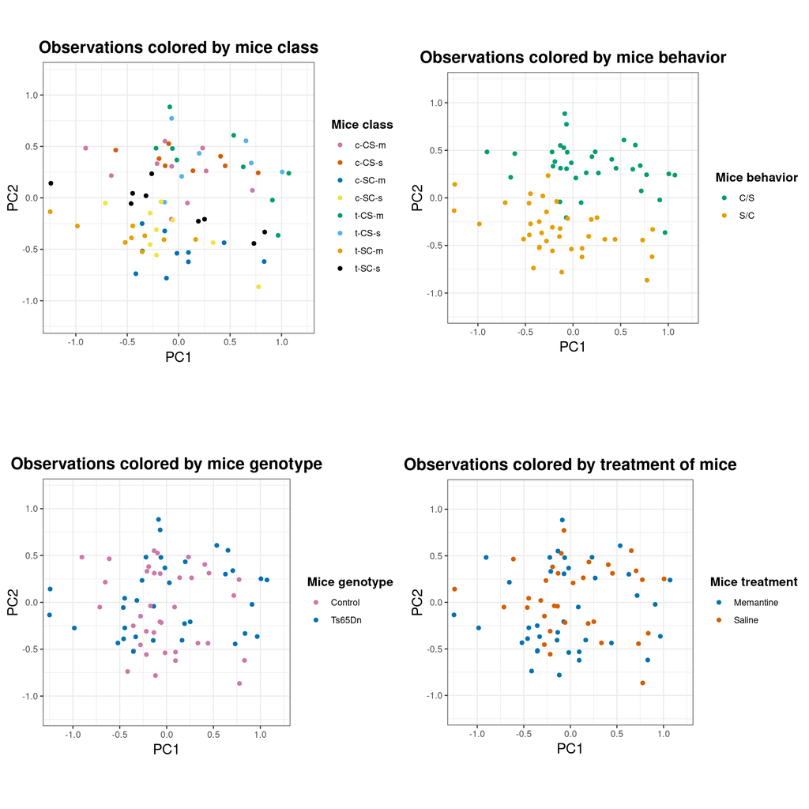

Looking at this chart we now can see dots that represent each mouse that participated in experiment. These mice can form clusters that represent degree of their similarity. We see that mice do not form clusters by class, treatment type and genotype. However there are 2 distinct clusters formed by control mice and mice that were stimulated to learn. Seems like they differ in production of various proteins.

It is interesting which features affect principal components the most. Here is factor loads of proteins sorted by absolute value.

|  | PC1 | PC2 | PC3 |
| --- | --- | --- | --- |
| CAMKII_N | -0.1975393 | 0.00722828 | -0.05000559 |
| MEK_N | -0.1929251 | 0.07222729 | 0.07156417 |
| pMEK_N | -0.1907543 | -0.03188552 | 0.01891425 |

|  | PC1 | PC2 | PC3 |
| --- | --- | --- | --- |
| GSK3B_N | -0.055146432 | 0.2258649 | 0.015642374 |
| SNCA_N | -0.071988630 | -0.2068872 | -0.013099707 |
| ITSN1_N | -0.001722793 | 0.2033856 | -0.009860671 |

|  | PC1 | PC2 | PC3 |
| --- | --- | --- | --- |
| pGSK3B_Tyr216_N | -0.01219121 | 0.09361693 | 0.2511804 |
| PSD95_N | -0.05969390 | -0.09058563 | 0.2495950 |
| CDK5_N | -0.05720678 | 0.12380093 | 0.2255457 |

We see that:

Proteins **CAMKII_N**, **MEK_N**, **pMEK_N** have high negative factor loads for PC1.

Proteins **GSK3B_N**, **ITSN1_N** have high factor loads for PC2 and **SNCA_N** has high negative factor load.

Proteins **pGSK3B_Tyr216_N**, **PSD95_N**, **CDK5_N** have high factor loads for PC3.

2d chart may be not very informative in our case, because we have only **0.4545** of cumulative proportion explained by 2 components. Thus we can draw 3d plots to include more information.

[interactive chart not shown]

Points are colored in the same way as on previous charts.

[interactive chart not shown]

## 2.4 Building linear model (principal components as predictors)

Now we performed dimension reduction with PCA and thus solved problem of multicollinearity. Now we can try to build linear model using principal components as predictors to predict *ERBB4_N* expression. For that purpose we will use 20 principal components (cumulative proportion explained = **0.951083**). Detailed summary can be found in supplementary [S11].

```
 PC1  PC2  PC3  PC4  PC5  PC6  PC7  PC8  PC9 PC10 PC11 PC12 PC13 PC14 PC15 PC16
   1    1    1    1    1    1    1    1    1    1    1    1    1    1    1    1
PC17 PC18 PC19 PC20
   1    1    1    1
```

We can see that all VIFs are equal 1, that happened because of PCA. Our model have several insignificant predictors, but we will keep them.

### 2.4.1 Usability conditions verification

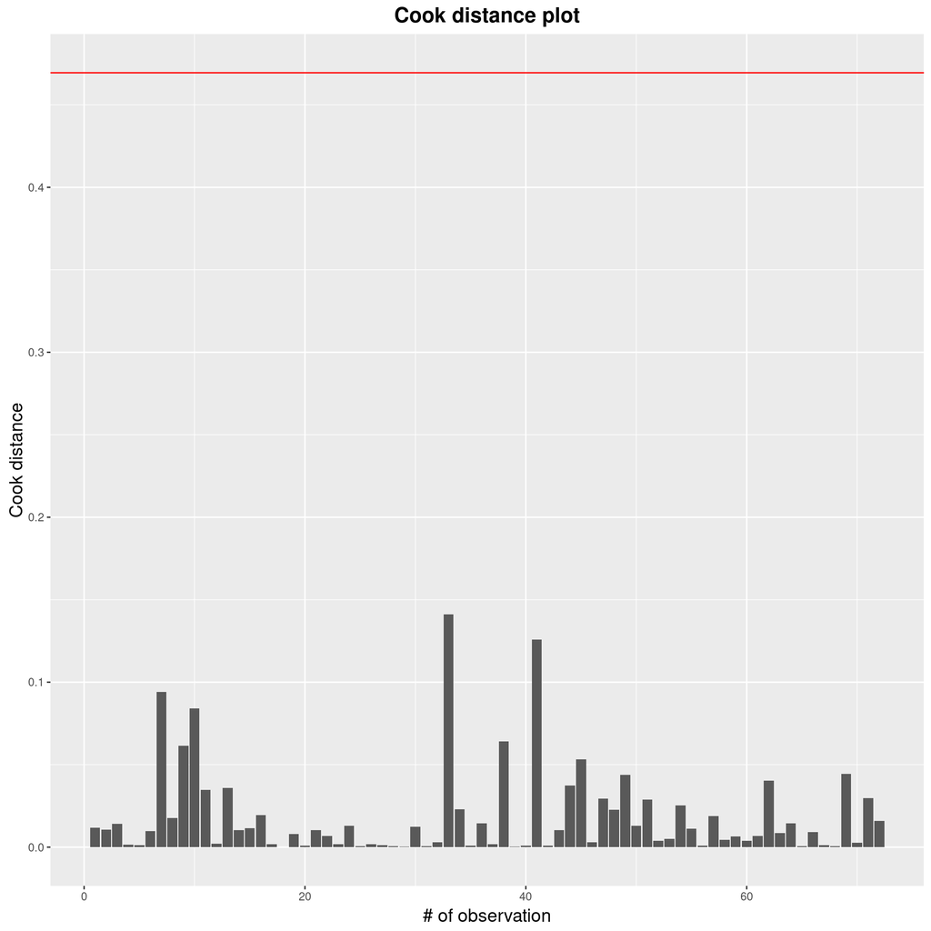

There are no influential observations in our data.

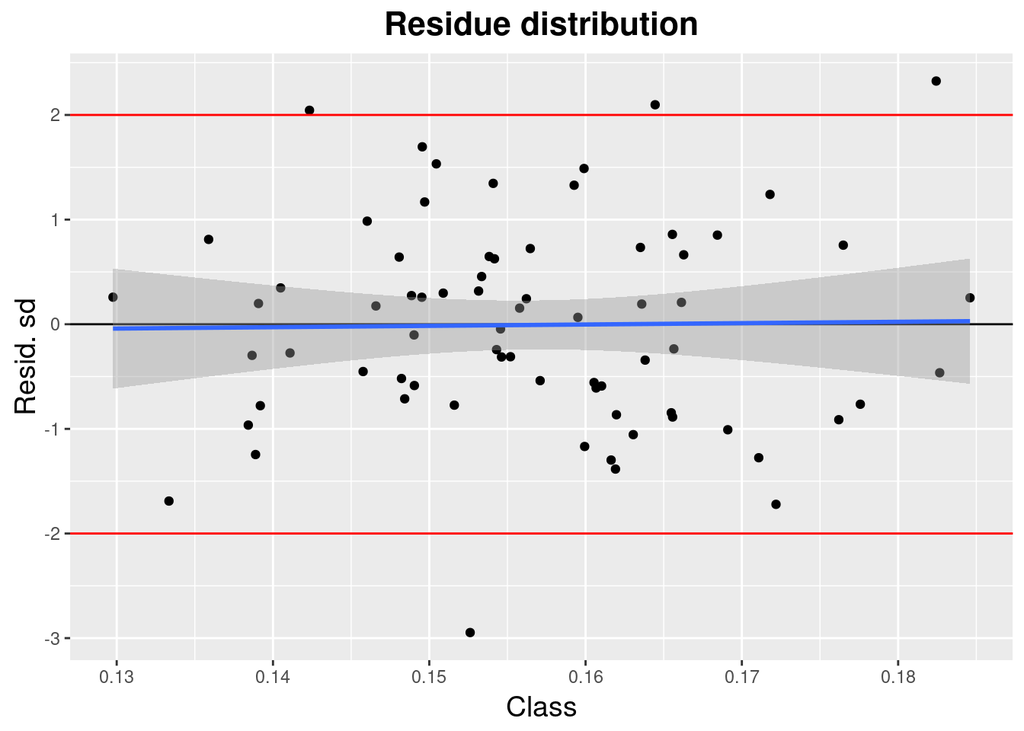

We cannot observe any patterns in residue distribution and there is less highly deviating observations than in previous attempt.

[figure not shown]

Now residue distribution became normal **(p-value = 0.7644, W = 0.9886)**.

Model (which is built using PC predictors) satisfies usability conditions and has greater r-squared **(R^2 = 0.9391)**.

In theory, this model could help us to predict protein expression using data about other proteins. However it might be hard to interpret slope coefficients as well as impact of individual proteins. At least we know that PCA could help us fight multicollinearity.

## 2.5 Protein expression analysis

Analysis of differential protein expression can be easily conducted with [limma package](https://www.rdocumentation.org/packages/limma/versions/3.28.14).

At first, we need to prepare our data. Rows must represent features (in our case features are protein names) and columns must represent observations (mice).

For that purpose we will transpose shrinked data obtained earlier. Also we need to create model matrix of different groups (*Behavior*, *Treatment*, *Genotype*). Then this matrix and our transposed data are passed to *lmFit* function that fits linear model for each gene. Resulting model is passed to *eBayes* function which computes t-statistic. Then top N differentially expressed proteins are extracted with *topTable* function. This function also allows us to set p-value adjustment method. Here we use conservative **bonferroni** adjustment in order to avoid I type errors.

After performing steps described above we got lists of differentially expressed proteins for each of groups.

**Differentially expressed proteins for *Behavior* group:**

|  | logFC | AveExpr | t | P.Value | adj.P.Val | B |
| --- | --- | --- | --- | --- | --- | --- |
| SOD1_N | 0.43 | 0.54 | 12 | 6.3e-18 | 4.9e-16 | 30 |
| CaNA_N | -0.47 | 1.3 | -11 | 1.1e-16 | 8.3e-15 | 27 |
| P38_N | 0.11 | 0.42 | 7.8 | 4.7e-11 | 3.6e-09 | 15 |
| Ubiquitin_N | 0.22 | 1.2 | 7.7 | 6.6e-11 | 5.1e-09 | 14 |
| SNCA_N | 0.024 | 0.16 | 7.3 | 2.7e-10 | 2.1e-08 | 13 |
| ARC_N | 0.016 | 0.12 | 6.9 | 2e-09 | 1.5e-07 | 11 |
| pS6_N | 0.016 | 0.12 | 6.9 | 2e-09 | 1.5e-07 | 11 |
| pERK_N | -0.4 | 0.55 | -6.7 | 4.2e-09 | 3.2e-07 | 10 |
| EGR1_N | 0.034 | 0.18 | 6.3 | 1.9e-08 | 1.4e-06 | 8.7 |
| H3MeK4_N | 0.048 | 0.2 | 6 | 8.2e-08 | 6.3e-06 | 7.2 |

[output cut: 17 more lines]

**Differentially expressed proteins for *Genotype* group:**

|  | logFC | AveExpr | t | P.Value | adj.P.Val | B |
| --- | --- | --- | --- | --- | --- | --- |
| APP_N | 0.064 | 0.4 | 7.1 | 8.6e-10 | 6.6e-08 | 12 |

**There is no differentially expressed proteins in *Treatment* group**

Data about all proteins in all groups can be found in supplementary materials:

- [S12] - Behavior
- [S13] - Treatment
- [S14] - Genotype

Such protein expression data can be visualized with volcano plot:

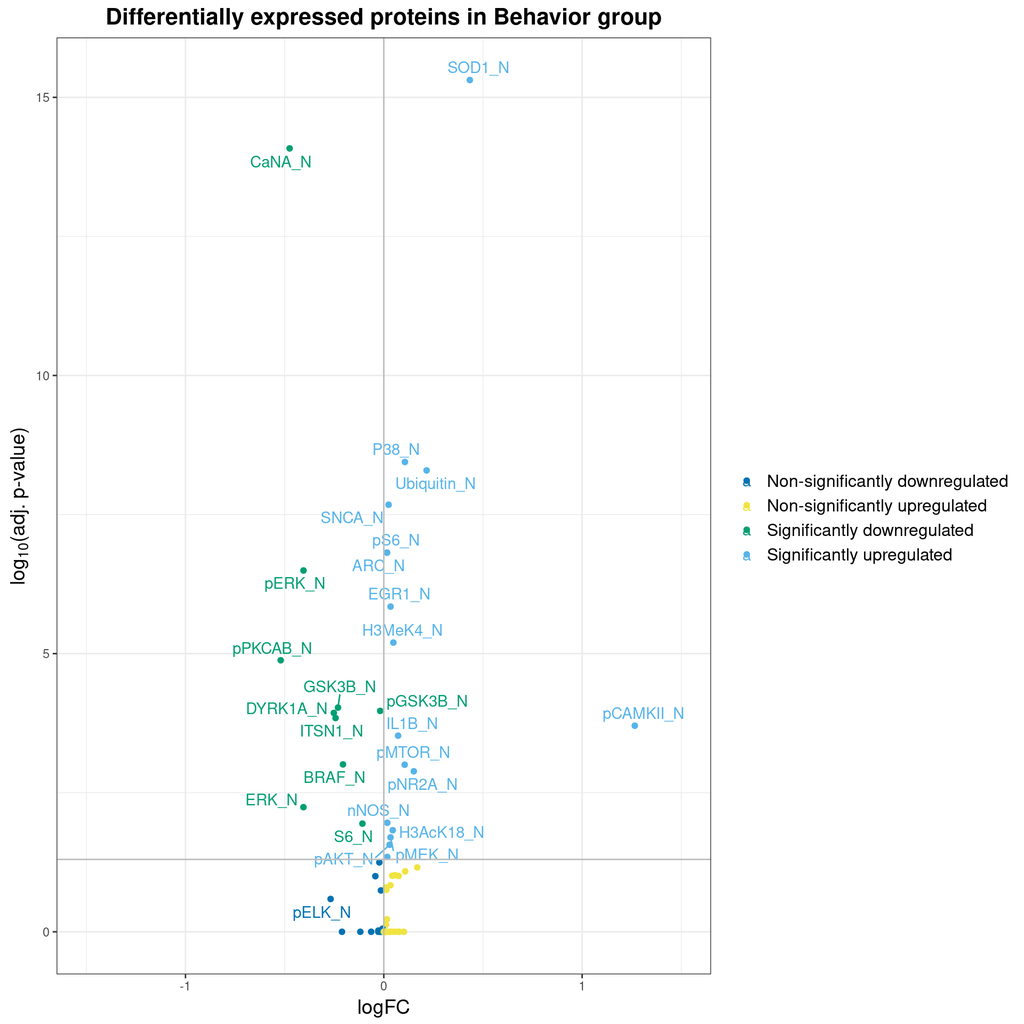

Here we can see that there are more upregulated proteins than downregulated. However downregulated proteins in general have larger absolute fold change. Nevertheless almost all FC are relatively small, which might indicate minor changes in mice phenotype.

# 3 Supplementary materials

**S1. Initial structure of the data**. Jump back

```
tibble [1,080 × 82] (S3: tbl_df/tbl/data.frame)
 $ MouseID        : chr [1:1080] "309_1" "309_2" "309_3" "309_4" ...
 $ DYRK1A_N       : num [1:1080] 0.504 0.515 0.509 0.442 0.435 ...
 $ ITSN1_N        : num [1:1080] 0.747 0.689 0.73 0.617 0.617 ...
 $ BDNF_N         : num [1:1080] 0.43 0.412 0.418 0.359 0.359 ...
 $ NR1_N          : num [1:1080] 2.82 2.79 2.69 2.47 2.37 ...
 $ NR2A_N         : num [1:1080] 5.99 5.69 5.62 4.98 4.72 ...
 $ pAKT_N         : num [1:1080] 0.219 0.212 0.209 0.223 0.213 ...
 $ pBRAF_N        : num [1:1080] 0.178 0.173 0.176 0.176 0.174 ...
 $ pCAMKII_N      : num [1:1080] 2.37 2.29 2.28 2.15 2.13 ...
 $ pCREB_N        : num [1:1080] 0.232 0.227 0.23 0.207 0.192 ...
 $ pELK_N         : num [1:1080] 1.75 1.6 1.56 1.6 1.5 ...
 $ pERK_N         : num [1:1080] 0.688 0.695 0.677 0.583 0.551 ...
 $ pJNK_N         : num [1:1080] 0.306 0.299 0.291 0.297 0.287 ...
 $ PKCA_N         : num [1:1080] 0.403 0.386 0.381 0.377 0.364 ...
```

[output cut: 68 more lines]

**S2. Data structure after making data “tidy”**. Jump back

```
tibble [1,080 × 83] (S3: tbl_df/tbl/data.frame)
 $ MouseID        : chr [1:1080] "309" "309" "309" "309" ...
 $ DYRK1A_N       : num [1:1080] 0.504 0.515 0.509 0.442 0.435 ...
 $ ITSN1_N        : num [1:1080] 0.747 0.689 0.73 0.617 0.617 ...
 $ BDNF_N         : num [1:1080] 0.43 0.412 0.418 0.359 0.359 ...
 $ NR1_N          : num [1:1080] 2.82 2.79 2.69 2.47 2.37 ...
 $ NR2A_N         : num [1:1080] 5.99 5.69 5.62 4.98 4.72 ...
 $ pAKT_N         : num [1:1080] 0.219 0.212 0.209 0.223 0.213 ...
 $ pBRAF_N        : num [1:1080] 0.178 0.173 0.176 0.176 0.174 ...
 $ pCAMKII_N      : num [1:1080] 2.37 2.29 2.28 2.15 2.13 ...
 $ pCREB_N        : num [1:1080] 0.232 0.227 0.23 0.207 0.192 ...
 $ pELK_N         : num [1:1080] 1.75 1.6 1.56 1.6 1.5 ...
 $ pERK_N         : num [1:1080] 0.688 0.695 0.677 0.583 0.551 ...
 $ pJNK_N         : num [1:1080] 0.306 0.299 0.291 0.297 0.287 ...
 $ PKCA_N         : num [1:1080] 0.403 0.386 0.381 0.377 0.364 ...
```

[output cut: 69 more lines]

**S3. Full linear model summary**. Jump back

```
Call:
lm(formula = ERBB4_N ~ . - MouseID - MeasurID - class - Treatment -
    Genotype - Behavior, data = mice_data)

Residuals:
      Min        1Q    Median        3Q       Max
-0.025516 -0.003834 -0.000075  0.003593  0.038233

Coefficients: (1 not defined because of singularities)
                  Estimate Std. Error t value Pr(>|t|)
(Intercept)      0.0274958  0.0057420   4.789 1.93e-06 ***
DYRK1A_N        -0.0077591  0.0054504  -1.424 0.154877
ITSN1_N          0.0121514  0.0059337   2.048 0.040833 *
BDNF_N          -0.0018158  0.0142494  -0.127 0.898624
NR1_N           -0.0066853  0.0038133  -1.753 0.079882 .
NR2A_N           0.0002810  0.0009857   0.285 0.775635
pAKT_N           0.0290597  0.0144957   2.005 0.045262 *
pBRAF_N         -0.0488960  0.0222090  -2.202 0.027919 *
pCAMKII_N       -0.0001033  0.0004580  -0.225 0.821664
pCREB_N         -0.0430923  0.0201837  -2.135 0.033002 *
pELK_N          -0.0007096  0.0009696  -0.732 0.464427
pERK_N          -0.0023965  0.0026422  -0.907 0.364612
pJNK_N          -0.0380089  0.0167366  -2.271 0.023358 *
PKCA_N           0.0414818  0.0156256   2.655 0.008063 **
pMEK_N          -0.0075635  0.0162765  -0.465 0.642256
pNR1_N          -0.0201548  0.0089399  -2.254 0.024380 *
pNR2A_N          0.0053618  0.0044320   1.210 0.226642
pNR2B_N          0.0033623  0.0038226   0.880 0.379295
pPKCAB_N         0.0019429  0.0019169   1.014 0.311055
pRSK_N           0.0155977  0.0088832   1.756 0.079416 .
AKT_N            0.0118477  0.0060490   1.959 0.050435 .
BRAF_N          -0.0104543  0.0067836  -1.541 0.123604
CAMKII_N         0.0243916  0.0133265   1.830 0.067501 .
CREB_N          -0.0282832  0.0201232  -1.406 0.160182
ELK_N            0.0022419  0.0026323   0.852 0.394574
ERK_N            0.0041749  0.0016293   2.562 0.010543 *
GSK3B_N          0.0025504  0.0040383   0.632 0.527820
JNK_N            0.0037357  0.0209840   0.178 0.858738
MEK_N            0.0063418  0.0140818   0.450 0.652554
TRKA_N           0.0015545  0.0086639   0.179 0.857645
```

[output cut: 38 more lines]

```
BAD_N           -0.0463235  0.0159592  -2.903 0.003782 **
BCL2_N           0.0122268  0.0149683   0.817 0.414210
pS6_N                   NA         NA      NA       NA
pCFOS_N         -0.0490420  0.0166173  -2.951 0.003238 **
SYP_N            0.0215151  0.0065234   3.298 0.001007 **
H3AcK18_N        0.0089403  0.0070752   1.264 0.206663
EGR1_N           0.0105255  0.0111806   0.941 0.346722
H3MeK4_N         0.0203880  0.0094645   2.154 0.031465 *
CaNA_N          -0.0065095  0.0024444  -2.663 0.007869 **
---
Signif. codes:  0 '***' 0.001 '**' 0.01 '*' 0.05 '.' 0.1 ' ' 1

Residual standard error: 0.006661 on 1004 degrees of freedom
Multiple R-squared:  0.8182,    Adjusted R-squared:  0.8046
F-statistic: 60.25 on 75 and 1004 DF,  p-value: < 2.2e-16
```

**S4. Variance inflation factors of predictors after removal of pS6_N**. Jump back

```
       DYRK1A_N         ITSN1_N          BDNF_N           NR1_N          NR2A_N
      44.807821       54.073873       12.007796       42.532262       20.517338
         pAKT_N         pBRAF_N       pCAMKII_N         pCREB_N          pELK_N
       8.835000        8.746842        8.538556       10.495956        4.972901
         pERK_N          pJNK_N          PKCA_N          pMEK_N          pNR1_N
      20.202296       18.351865       16.156089       13.694438       26.973124
        pNR2A_N         pNR2B_N        pPKCAB_N          pRSK_N           AKT_N
      16.840731       25.987996       20.682571        8.513558       14.409174
         BRAF_N        CAMKII_N          CREB_N           ELK_N           ERK_N
      52.275059       11.803356        6.829365       18.713024       27.485327
        GSK3B_N           JNK_N           MEK_N          TRKA_N           RSK_N
      23.692339       12.271350        8.086172       26.572626       12.090341
          APP_N      Bcatenin_N          SOD1_N          MTOR_N           P38_N
       6.344710       37.550805        8.203507       14.916410       14.678849
        pMTOR_N         DSCR1_N         AMPKA_N          NR2B_N         pNUMB_N
      11.979259        9.371754       22.415257        8.605554       16.008886
       RAPTOR_N         TIAM1_N        pP70S6_N          NUMB_N         P70S6_N
      19.631134       16.178653        8.985047       11.772174        9.204233
       pGSK3B_N         pPKCG_N          CDK5_N            S6_N        ADARB1_N
       6.083727       14.154825        3.027777        8.812942        6.074277
   AcetylH3K9_N          RRP1_N           BAX_N           ARC_N          nNOS_N
      14.703563        2.121039        4.909060        7.850880        5.394238
          Tau_N          GFAP_N         GluR3_N         GluR4_N          IL1B_N
      14.539923        4.131776        4.630194        2.202969        8.958019
        P3525_N        pCASP9_N         PSD95_N          SNCA_N     Ubiquitin_N
       5.625320        7.280353        6.942966        8.191988        8.137325
pGSK3B_Tyr216_N           SHH_N           BAD_N          BCL2_N         pCFOS_N
       9.171033        3.363377        4.430391        3.191940        3.575784
          SYP_N       H3AcK18_N          EGR1_N        H3MeK4_N          CaNA_N
       4.566674        3.857973        4.264088        5.458854       14.612223
```

**S5. Summary of model selected via backward selection** . Jump back

```
Call:
lm(formula = ERBB4_N ~ DYRK1A_N + ITSN1_N + NR1_N + pAKT_N +
    pBRAF_N + pCREB_N + pJNK_N + PKCA_N + pNR1_N + pNR2B_N +
    pRSK_N + AKT_N + BRAF_N + CAMKII_N + ERK_N + SOD1_N + MTOR_N +
    pMTOR_N + TIAM1_N + P70S6_N + pGSK3B_N + pPKCG_N + AcetylH3K9_N +
    RRP1_N + ARC_N + Tau_N + GFAP_N + GluR3_N + GluR4_N + IL1B_N +
    P3525_N + pCASP9_N + PSD95_N + pGSK3B_Tyr216_N + BAD_N +
    pCFOS_N + SYP_N + EGR1_N + H3MeK4_N + CaNA_N, data = mice_data)

Residuals:
      Min        1Q    Median        3Q       Max
-0.025326 -0.003985  0.000075  0.003615  0.038744

Coefficients:
                  Estimate Std. Error t value Pr(>|t|)
(Intercept)      0.0243836  0.0047667   5.115 3.73e-07 ***
DYRK1A_N        -0.0106084  0.0047983  -2.211 0.027263 *
ITSN1_N          0.0118337  0.0047972   2.467 0.013792 *
NR1_N           -0.0072305  0.0032895  -2.198 0.028164 *
pAKT_N           0.0355315  0.0125315   2.835 0.004666 **
pBRAF_N         -0.0509109  0.0190303  -2.675 0.007585 **
pCREB_N         -0.0299997  0.0145010  -2.069 0.038811 *
pJNK_N          -0.0303308  0.0112899  -2.687 0.007335 **
PKCA_N           0.0512038  0.0117881   4.344 1.54e-05 ***
pNR1_N          -0.0160239  0.0078366  -2.045 0.041131 *
pNR2B_N          0.0052372  0.0026201   1.999 0.045890 *
pRSK_N           0.0138680  0.0070470   1.968 0.049341 *
AKT_N            0.0083296  0.0043352   1.921 0.054952 .
BRAF_N          -0.0081795  0.0051416  -1.591 0.111944
CAMKII_N         0.0293573  0.0103442   2.838 0.004627 **
ERK_N            0.0047946  0.0011154   4.299 1.88e-05 ***
SOD1_N          -0.0023213  0.0013315  -1.743 0.081573 .
MTOR_N           0.0395444  0.0087832   4.502 7.48e-06 ***
pMTOR_N         -0.0110594  0.0044270  -2.498 0.012637 *
TIAM1_N         -0.0175187  0.0078958  -2.219 0.026720 *
P70S6_N         -0.0087164  0.0027687  -3.148 0.001690 **
pGSK3B_N         0.0598303  0.0223509   2.677 0.007548 **
pPKCG_N         -0.0061611  0.0008782  -7.016 4.12e-12 ***
AcetylH3K9_N     0.0073235  0.0034341   2.133 0.033195 *
RRP1_N          -0.0215609  0.0085295  -2.528 0.011626 *
ARC_N            0.1648258  0.0311702   5.288 1.51e-07 ***
Tau_N            0.0417955  0.0086159   4.851 1.42e-06 ***
GFAP_N          -0.0563194  0.0267838  -2.103 0.035729 *
GluR3_N         -0.0225796  0.0102770  -2.197 0.028233 *
GluR4_N         -0.0217506  0.0106192  -2.048 0.040788 *
IL1B_N           0.0231380  0.0061146   3.784 0.000163 ***
P3525_N          0.0976934  0.0123329   7.921 6.01e-15 ***
pCASP9_N         0.0124217  0.0017467   7.111 2.14e-12 ***
PSD95_N          0.0170533  0.0017880   9.538  < 2e-16 ***
pGSK3B_Tyr216_N  0.0240613  0.0045637   5.272 1.64e-07 ***
BAD_N           -0.0332052  0.0143615  -2.312 0.020967 *
pCFOS_N         -0.0454107  0.0139452  -3.256 0.001165 **
SYP_N            0.0209904  0.0053063   3.956 8.15e-05 ***
EGR1_N           0.0151632  0.0100660   1.506 0.132274
H3MeK4_N         0.0219242  0.0086933   2.522 0.011819 *
CaNA_N          -0.0057407  0.0017257  -3.327 0.000910 ***
---
Signif. codes:  0 '***' 0.001 '**' 0.01 '*' 0.05 '.' 0.1 ' ' 1

Residual standard error: 0.00661 on 1039 degrees of freedom
Multiple R-squared:  0.8147,    Adjusted R-squared:  0.8076
F-statistic: 114.2 on 40 and 1039 DF,  p-value: < 2.2e-16
```

**S6. VIFs of model selected via backward selection** . Jump back

```
       DYRK1A_N         ITSN1_N           NR1_N          pAKT_N         pBRAF_N
      35.266944       35.891249       32.140030        6.705238        6.521757
        pCREB_N          pJNK_N          PKCA_N          pNR1_N         pNR2B_N
       5.501711        8.480152        9.337562       21.047728       12.398967
         pRSK_N           AKT_N          BRAF_N        CAMKII_N           ERK_N
       5.440812        7.515502       30.496099        7.221819       13.079401
         SOD1_N          MTOR_N         pMTOR_N         TIAM1_N         P70S6_N
       3.440551        8.147603        7.236255        6.955142        5.654877
       pGSK3B_N         pPKCG_N    AcetylH3K9_N          RRP1_N           ARC_N
       4.598786        6.372078       10.000122        1.827656        4.889930
          Tau_N          GFAP_N         GluR3_N         GluR4_N          IL1B_N
       8.729925        3.102164        3.174025        2.012727        6.216523
        P3525_N        pCASP9_N         PSD95_N pGSK3B_Tyr216_N           BAD_N
       3.383682        4.638798        5.108898        4.574468        3.643365
        pCFOS_N           SYP_N          EGR1_N        H3MeK4_N          CaNA_N
       2.557300        3.068494        3.509866        4.676896        7.395380
```

**S7. Summary of manually selected model**. Jump back

```
Call:
lm(formula = ERBB4_N ~ pJNK_N + ELK_N + nNOS_N + Tau_N + IL1B_N,
    data = mice_data)

Residuals:
      Min        1Q    Median        3Q       Max
-0.036069 -0.005931  0.000111  0.005756  0.037386

Coefficients:
            Estimate Std. Error t value Pr(>|t|)
(Intercept) 0.051879   0.002723  19.050  < 2e-16 ***
pJNK_N      0.048004   0.005986   8.019 2.77e-15 ***
ELK_N       0.011063   0.001032  10.720  < 2e-16 ***
nNOS_N      0.082534   0.014304   5.770 1.04e-08 ***
Tau_N       0.044336   0.004383  10.114  < 2e-16 ***
IL1B_N      0.099086   0.004063  24.389  < 2e-16 ***
---
Signif. codes:  0 '***' 0.001 '**' 0.01 '*' 0.05 '.' 0.1 ' ' 1

Residual standard error: 0.009422 on 1074 degrees of freedom
Multiple R-squared:  0.611, Adjusted R-squared:  0.6092
F-statistic: 337.3 on 5 and 1074 DF,  p-value: < 2.2e-16
```

**S8. VIFs of manually selected model**. Jump back

```
  pJNK_N    ELK_N   nNOS_N    Tau_N   IL1B_N
1.173589 1.437806 1.544355 1.112233 1.350954
```

**S9. Data containing average (of 15 measurements) protein production for each mouse**. Jump back

| MouseID | class | Treatment | Behavior | Genotype | DYRK1A_N | ITSN1_N | BDNF_N | NR1_N | NR2A_N | pAKT_N | pBRAF_N | pCAMKII_N | pCREB_N | pELK_N | pERK_N | pJNK_N | PKCA_N | pMEK_N | pNR1_N | pNR2A_N | pNR2B_N | pPKCAB_N | pRSK_N | AKT_N | BRAF_N | CAMKII_N | CREB_N | ELK_N | ERK_N | … |
| --- | --- | --- | --- | --- | --- | --- | --- | --- | --- | --- | --- | --- | --- | --- | --- | --- | --- | --- | --- | --- | --- | --- | --- | --- | --- | --- | --- | --- | --- | --- |
| 18899 | t-CS-s | Saline | C/S | Ts65Dn | 0.4283814 | 0.6178336 | 0.2992076 | 2.053351 | 3.461564 | 0.2819445 | 0.1911497 | 2.541373 | 0.2108445 | 1.5569773 | 0.6128008 | 0.3425459 | 0.2984092 | 0.3081845 | 0.7554557 | 0.7091128 | 1.503607 | 1.2650442 | 0.4199606 | 0.6623708 | 0.4236938 | 0.4001615 | 0.1857758 | 1.0258213 | 2.778275 | … |
| 293 | t-SC-m | Memantine | S/C | Ts65Dn | 0.2680720 | 0.5327365 | 0.2932740 | 2.278292 | 3.466264 | 0.2555946 | 0.1937011 | 3.825613 | 0.2403963 | 1.2032262 | 0.3025830 | 0.3296394 | 0.2909124 | 0.2926914 | 0.8465221 | 0.8435151 | 1.581187 | 0.9574458 | 0.4834611 | 0.6667995 | 0.2714182 | 0.3693785 | 0.1966274 | 1.1790732 | 2.371455 | … |
| 294 | c-SC-m | Memantine | S/C | Control | 0.3180004 | 0.4865845 | 0.3159795 | 2.479140 | 3.838981 | 0.2612305 | 0.2049781 | 5.130094 | 0.2236103 | 1.3650916 | 0.4075212 | 0.3450642 | 0.3041478 | 0.2946679 | 0.9034297 | 0.8937337 | 1.812742 | 1.1676340 | 0.4218618 | 0.6775179 | 0.3055584 | 0.3972279 | 0.1936766 | 1.0427415 | 2.218746 | … |
| 309 | c-CS-m | Memantine | C/S | Control | 0.4210633 | 0.5765104 | 0.3564467 | 2.278252 | 4.354744 | 0.2195494 | 0.1821951 | 1.922373 | 0.1960636 | 1.4229325 | 0.5316278 | 0.2889352 | 0.3651359 | 0.2742084 | 0.8279591 | 0.4901698 | 1.443469 | 1.8990618 | 0.4779889 | 0.6445691 | 0.3671376 | 0.3576063 | 0.1852794 | 1.1706124 | 2.624528 | … |
| 311 | c-CS-m | Memantine | C/S | Control | 0.6005906 | 0.6784788 | 0.3345483 | 2.277561 | 4.234706 | 0.2278204 | 0.1842621 | 1.931669 | 0.1765107 | 1.8743066 | 0.8548323 | 0.3298016 | 0.3490251 | 0.2723827 | 0.8362063 | 0.6518521 | 1.531520 | 1.4283258 | 0.4044717 | 0.7097709 | 0.4776554 | 0.3703156 | 0.1845352 | 1.0903243 | 2.958024 | … |
| 320 | c-CS-m | Memantine | C/S | Control | 0.5476756 | 0.7960124 | 0.3986493 | 2.664515 | 5.498960 | 0.2413906 | 0.1940966 | 2.406303 | 0.2183635 | 1.8154227 | 0.8611394 | 0.3523808 | 0.3538090 | 0.2748493 | 0.9734708 | 0.8495566 | 1.921312 | 1.8138303 | 0.3945850 | 0.9219050 | 0.4893055 | 0.4273612 | 0.1945694 | 1.7120128 | 3.829943 | … |
| 321 | c-CS-m | Memantine | C/S | Control | 0.4387284 | 0.6520446 | 0.3594414 | 2.686405 | 5.298355 | 0.2318758 | 0.1848745 | 2.502274 | 0.1991094 | 1.5350176 | 0.6754630 | 0.3338963 | 0.3264387 | 0.2672256 | 0.9741008 | 0.7497686 | 1.868645 | 1.5602546 | 0.3950017 | 0.8297164 | 0.3803942 | 0.4170719 | 0.1846196 | 1.5104438 | 3.449440 | … |
| 322 | c-CS-m | Memantine | C/S | Control | 0.3589312 | 0.5122230 | 0.3151045 | 2.111664 | 4.231444 | 0.2324153 | 0.1839951 | 3.574599 | 0.1823085 | 1.2450661 | 0.5602867 | 0.3383553 | 0.2970792 | 0.2570550 | 0.7945171 | 0.8017265 | 1.578471 | 1.1388346 | 0.3732066 | 0.7070231 | 0.3127147 | 0.3821060 | 0.1709921 | 1.0828725 | 2.832684 | … |
| 3411 | t-SC-m | Memantine | S/C | Ts65Dn | 0.2976333 | 0.5311198 | 0.3067379 | 2.299533 | 4.018452 | 0.2406865 | 0.1959823 | 3.315139 | 0.2389734 | 1.4110658 | 0.3250906 | 0.3394993 | 0.3203326 | 0.3012116 | 0.8079096 | 0.8976189 | 1.609315 | 1.1431821 | 0.4265894 | 0.7817769 | 0.2347110 | 0.3635649 | 0.1858296 | 1.2213851 | 2.588806 | … |
| 3412 | c-SC-m | Memantine | S/C | Control | 0.2757780 | 0.4266809 | 0.3054192 | 2.285876 | 3.561400 | 0.2719667 | 0.2088254 | 6.056395 | 0.2205909 | 1.2380854 | 0.4010317 | 0.3986896 | 0.3077595 | 0.3077890 | 0.8777945 | 1.1988312 | 1.737695 | 1.2109977 | 0.5036309 | 0.6637181 | 0.2671541 | 0.3741982 | 0.1930099 | 1.0774614 | 2.025852 | … |

[output cut: 62 more lines]

**S10. PCA summary**. Jump back

```
Call:
rda(X = mice_shrinked[, -c(1:5)], scale = TRUE)

Partitioning of correlations:
              Inertia Proportion
Total              77          1
Unconstrained      77          1

Eigenvalues, and their contribution to the correlations

Importance of components:
                          PC1     PC2     PC3    PC4     PC5     PC6     PC7
Eigenvalue            19.7478 15.2455 7.30189 6.0679 4.53625 3.81492 2.97175
Proportion Explained   0.2565  0.1980 0.09483 0.0788 0.05891 0.04954 0.03859
Cumulative Proportion  0.2565  0.4545 0.54929 0.6281 0.68700 0.73655 0.77514
                          PC8     PC9    PC10    PC11    PC12    PC13    PC14
Eigenvalue            2.63706 1.92278 1.47536 1.23138 1.10316 0.93775 0.83704
Proportion Explained  0.03425 0.02497 0.01916 0.01599 0.01433 0.01218 0.01087
Cumulative Proportion 0.80939 0.83436 0.85352 0.86951 0.88384 0.89602 0.90689
                          PC15     PC16     PC17     PC18    PC19     PC20
Eigenvalue            0.711669 0.686360 0.566138 0.518835 0.46588 0.453983
Proportion Explained  0.009242 0.008914 0.007352 0.006738 0.00605 0.005896
Cumulative Proportion 0.916132 0.925046 0.932399 0.939137 0.94519 0.951083
                          PC21     PC22     PC23     PC24     PC25     PC26
Eigenvalue            0.384550 0.341409 0.307136 0.278217 0.274459 0.235704
Proportion Explained  0.004994 0.004434 0.003989 0.003613 0.003564 0.003061
Cumulative Proportion 0.956077 0.960511 0.964500 0.968113 0.971677 0.974738
                          PC27     PC28    PC29     PC30     PC31     PC32
Eigenvalue            0.189834 0.170555 0.15865 0.150288 0.130736 0.117447
Proportion Explained  0.002465 0.002215 0.00206 0.001952 0.001698 0.001525
Cumulative Proportion 0.977204 0.979419 0.98148 0.983431 0.985129 0.986654
                          PC33     PC34     PC35     PC36      PC37      PC38
Eigenvalue            0.106908 0.103059 0.093225 0.082696 0.0737727 0.0559883
Proportion Explained  0.001388 0.001338 0.001211 0.001074 0.0009581 0.0007271
Cumulative Proportion 0.988043 0.989381 0.990592 0.991666 0.9926238 0.9933509
                           PC39      PC40      PC41      PC42      PC43
Eigenvalue            0.0538278 0.0488077 0.0420735 0.0412055 0.0387133
Proportion Explained  0.0006991 0.0006339 0.0005464 0.0005351 0.0005028
Cumulative Proportion 0.9940500 0.9946839 0.9952303 0.9957654 0.9962682
                           PC44      PC45      PC46      PC47      PC48
```

[output cut: 172 more lines]

```
sit58  0.32540 -0.90874 -0.48154 -1.378424  0.59431 -0.539696
sit59 -0.43499  1.08437  0.61130  0.111994  0.26824 -1.261095
sit60  0.87153 -0.97936 -1.67187 -0.868007  1.44136 -0.680779
sit61 -0.03591  0.82751  0.44694  1.878317  0.32202 -1.478367
sit62 -0.70230 -0.56181  0.14691 -0.297218  1.94882  0.309242
sit63 -0.26792 -0.72352  0.69645 -0.661284  0.46885  0.403589
sit64  0.27379  0.59237  2.55928 -1.058848 -2.24877 -0.162185
sit65  1.39392  0.76146 -0.82316 -1.402972 -0.69642  0.450545
sit66 -0.13618  1.73760  1.02036 -0.659778 -0.32633 -0.264099
sit67  0.80398  0.90914  0.87813 -0.134444 -0.95387 -0.741242
sit68  0.39284  0.97332  0.89053  0.678605 -0.96228  0.148243
sit69 -0.25996  0.70100 -1.45477  1.364840  0.77643  2.173774
sit70  0.49641 -0.46627  0.23601  2.476178  1.33133  0.157400
sit71 -0.55002 -0.33123  0.38056  0.259356 -0.58558 -1.640964
sit72  0.37768 -0.50987  1.48317  1.887497 -0.54134  0.576232
```

**S11. Linear model summary (PC as predictors)**. Jump back

```
Call:
lm(formula = ERBB4_N ~ PC1 + PC2 + PC3 + PC4 + PC5 + PC6 + PC7 +
    PC8 + PC9 + PC10 + PC11 + PC12 + PC13 + PC14 + PC15 + PC16 +
    PC17 + PC18 + PC19 + PC20, data = pca_linmod_dat)

Residuals:
       Min         1Q     Median         3Q        Max
-0.0078247 -0.0015359  0.0000387  0.0015989  0.0060313

Coefficients:
              Estimate Std. Error t value Pr(>|t|)
(Intercept)  0.1564775  0.0003574 437.854  < 2e-16 ***
PC1         -0.0111544  0.0006964 -16.018  < 2e-16 ***
PC2         -0.0097543  0.0007925 -12.308  < 2e-16 ***
PC3          0.0234251  0.0011452  20.455  < 2e-16 ***
PC4         -0.0048247  0.0012563  -3.841 0.000341 ***
PC5         -0.0077966  0.0014529  -5.366 1.98e-06 ***
PC6          0.0040118  0.0015844   2.532 0.014460 *
PC7         -0.0131281  0.0017951  -7.313 1.74e-09 ***
PC8         -0.0145933  0.0019056  -7.658 4.99e-10 ***
PC9         -0.0103333  0.0022317  -4.630 2.55e-05 ***
PC10         0.0003086  0.0025477   0.121 0.904063
PC11        -0.0079202  0.0027887  -2.840 0.006464 **
PC12        -0.0227894  0.0029463  -7.735 3.78e-10 ***
PC13         0.0039287  0.0031956   1.229 0.224564
PC14         0.0115374  0.0033824   3.411 0.001274 **
PC15         0.0086574  0.0036682   2.360 0.022134 *
PC16        -0.0036379  0.0037353  -0.974 0.334686
PC17        -0.0145119  0.0041128  -3.528 0.000895 ***
PC18         0.0045248  0.0042962   1.053 0.297207
PC19        -0.0054948  0.0045338  -1.212 0.231109
PC20        -0.0081863  0.0045928  -1.782 0.080635 .
---
Signif. codes:  0 '***' 0.001 '**' 0.01 '*' 0.05 '.' 0.1 ' ' 1

Residual standard error: 0.003032 on 51 degrees of freedom
Multiple R-squared:  0.9563,    Adjusted R-squared:  0.9391
F-statistic: 55.79 on 20 and 51 DF,  p-value: < 2.2e-16
```

**S12. Differential protein expression data for *Behavior* group**. Jump back

|  | logFC | AveExpr | t | P.Value | adj.P.Val | B | diffexpressed | labels |
| --- | --- | --- | --- | --- | --- | --- | --- | --- |
| SOD1_N | 0.4336003314 | 0.5431312 | 11.52789688 | 6.342285e-18 | 4.883560e-16 | 30.31224674 | Significantly upregulated | SOD1_N |
| CaNA_N | -0.4748737900 | 1.3377837 | -10.83444824 | 1.073910e-16 | 8.269110e-15 | 27.49203529 | Significantly downregulated | CaNA_N |
| P38_N | 0.1064275061 | 0.4153393 | 7.76030052 | 4.658228e-11 | 3.586836e-09 | 14.57622903 | Significantly upregulated | P38_N |
| Ubiquitin_N | 0.2156695550 | 1.2392704 | 7.67824998 | 6.608851e-11 | 5.088815e-09 | 14.22927474 | Significantly upregulated | Ubiquitin_N |
| SNCA_N | 0.0240137482 | 0.1598210 | 7.34454608 | 2.733446e-10 | 2.104754e-08 | 12.82197325 | Significantly upregulated | SNCA_N |
| ARC_N | 0.0160992566 | 0.1215208 | 6.87593712 | 1.983214e-09 | 1.527075e-07 | 10.86066988 | Significantly upregulated | ARC_N |
| pS6_N | 0.0160992566 | 0.1215208 | 6.87593712 | 1.983214e-09 | 1.527075e-07 | 10.86066988 | Significantly upregulated | pS6_N |
| pERK_N | -0.4048983405 | 0.5453814 | -6.69962959 | 4.158436e-09 | 3.201996e-07 | 10.12896782 | Significantly downregulated | pERK_N |
| EGR1_N | 0.0339846519 | 0.1835572 | 6.34090919 | 1.853916e-08 | 1.427515e-06 | 8.65394876 | Significantly upregulated | EGR1_N |
| H3MeK4_N | 0.0482268048 | 0.2048722 | 5.97889931 | 8.213868e-08 | 6.324678e-06 | 7.18838163 | Significantly upregulated | H3MeK4_N |

[output cut: 67 more lines]

**S13. Differential protein expression data for *Treatment* group**. Jump back

|  | logFC | AveExpr | t | P.Value | adj.P.Val | B | diffexpressed | labels |
| --- | --- | --- | --- | --- | --- | --- | --- | --- |
| NUMB_N | 1.452357e-02 | 0.1810801 | 3.147237348 | 0.002409931 | 0.1855647 | -2.410267 | Non-significantly upregulated | NUMB_N |
| ELK_N | 1.044150e-01 | 1.1750290 | 2.516818110 | 0.014103346 | 1.0000000 | -4.022534 | Non-significantly upregulated | ELK_N |
| P3525_N | 1.274547e-02 | 0.2912763 | 2.300610655 | 0.024355824 | 1.0000000 | -4.506984 | Non-significantly upregulated | P3525_N |
| pGSK3B_N | 8.681777e-03 | 0.1612110 | 2.181352765 | 0.032471778 | 1.0000000 | -4.758188 | Non-significantly upregulated | pGSK3B_N |
| IL1B_N | -3.535802e-02 | 0.5273487 | -2.178832782 | 0.032666208 | 1.0000000 | -4.763371 | Non-significantly downregulated | IL1B_N |
| pMTOR_N | -5.405372e-02 | 0.7589883 | -2.171522069 | 0.033236041 | 1.0000000 | -4.778376 | Non-significantly downregulated | pMTOR_N |
| GFAP_N | 5.356155e-03 | 0.1208891 | 2.075512486 | 0.041564304 | 1.0000000 | -4.971324 | Non-significantly upregulated | GFAP_N |
| S6_N | 5.926538e-02 | 0.4292256 | 2.044938141 | 0.044570574 | 1.0000000 | -5.031151 | Non-significantly upregulated | S6_N |
| P38_N | -3.672727e-02 | 0.4153393 | -2.022886150 | 0.046853507 | 1.0000000 | -5.073811 | Non-significantly downregulated | P38_N |
| pBRAF_N | -1.012640e-02 | 0.1818561 | -2.002161915 | 0.049089853 | 1.0000000 | -5.113528 | Non-significantly downregulated | pBRAF_N |

[output cut: 67 more lines]

**S14. Differential protein expression data for *Genotype* group**. Jump back

|  | logFC | AveExpr | t | P.Value | adj.P.Val | B | diffexpressed | labels |
| --- | --- | --- | --- | --- | --- | --- | --- | --- |
| APP_N | 0.0641589419 | 0.4049064 | 7.07538864 | 8.556209e-10 | 6.588281e-08 | 11.953107 | Significantly upregulated | APP_N |
| S6_N | 0.0943782031 | 0.4292256 | 3.41473486 | 1.059166e-03 | 8.155575e-02 | -1.646271 | Non-significantly upregulated | S6_N |
| GluR3_N | -0.0180985350 | 0.2218510 | -2.61500182 | 1.089078e-02 | 8.385899e-01 | -3.793079 | Non-significantly downregulated | GluR3_N |
| Tau_N | 0.0375705572 | 0.2104892 | 2.55603991 | 1.272939e-02 | 9.801634e-01 | -3.933290 | Non-significantly upregulated | Tau_N |
| H3AcK18_N | 0.0305554495 | 0.1712476 | 2.52263174 | 1.389155e-02 | 1.000000e+00 | -4.011556 | Non-significantly upregulated | H3AcK18_N |
| pPKCG_N | 0.3168856529 | 1.7065987 | 2.46560192 | 1.609804e-02 | 1.000000e+00 | -4.143171 | Non-significantly upregulated | pPKCG_N |
| pNR1_N | -0.0438400761 | 0.8257515 | -2.40563900 | 1.875258e-02 | 1.000000e+00 | -4.278820 | Non-significantly downregulated | pNR1_N |
| pNR2A_N | -0.0860997705 | 0.7267820 | -2.39277547 | 1.937062e-02 | 1.000000e+00 | -4.307552 | Non-significantly downregulated | pNR2A_N |
| SYP_N | -0.0302877088 | 0.4460730 | -2.33094530 | 2.260198e-02 | 1.000000e+00 | -4.443820 | Non-significantly downregulated | SYP_N |
| MTOR_N | -0.0294220212 | 0.4524828 | -2.22996805 | 2.891404e-02 | 1.000000e+00 | -4.659766 | Non-significantly downregulated | MTOR_N |

[output cut: 67 more lines]